# Cyclistic Bikes Share a Case Study

Sonny Boy Bocala

2023-10-04

# INTRODUCTION

The main goal now is to examine and understand the variations in usage styles between annual members and casual cyclists. The study intends to shed light on how these two user groups use the bike-sharing services offered by Cyclistic in various ways. The final objective is to use these insights to create a focused marketing plan that aims to turn occasional riders into yearly subscribers. The analysis will be supported by data from previous bike trips, and the conclusions will be vital in guiding Cyclistic’s data-driven decision-making.

This commercial endeavor supports Cyclistic’s strategic goal of increasing the number of annual subscriptions because it has been determined that these members are more profitable than casual riders. The analysis will serve as the basis for suggestions to improve the business’s marketing initiatives and promote annual membership growth.

The insights drawn from the study will directly influence Cyclistic’s marketing plan. These data will specifically lead the formulation of a marketing plan meant to turn casual riders into yearly subscribers. Here is how business decisions will be affected the outcomes:

Segmented marketing: Cyclistic executive team may improve its marketing efforts by comprehending the variations in usage patterns between annual members and casual riders. For instance, incentives and promotions can be created to specifically target casual riders based on their requirements and preferences.

Pricing and Membership Plans: Cyclistic executive team can improve its pricing strategies and membership plans by learning more about the reasons casual cyclists might think about purchasing annual subscriptions. This can entail developing more enticing membership plans that align with the interests of casual riders.

**Brief background and summary of case study company**

Cyclistic is a bike-share company in Chicago. It has a fleet of over 5,800 bicycles and 692 stations across the city. Cyclistic’s customers can purchase single-ride passes, full-day passes, or annual memberships. Single-ride passes and full-day passes are popular with casual riders, while annual memberships are popular with people who use Cyclistic bikes on a regular basis.

Cyclistic’s director of marketing, Lily Moreno, believes that the company’s future success depends on maximizing the number of annual members. Therefore, she has assigned her team to analyze the data to identify how annual members and casual riders use Cyclistic bikes differently. This information will be used to design a new marketing strategy to convert casual riders into annual members.

# ASK PHASE

The problem we are trying to solve in the Cyclistic scenario is understanding how annual members and casual riders use Cyclistic bikes differently. This understanding is crucial to designing a marketing strategy to convert casual riders into annual members effectively. Our insights will drive business decisions by providing data-driven recommendations for designing a marketing strategy. By understanding the differences in bike usage between these two customer groups, Cyclistic can tailor its marketing efforts to target casual riders more effectively and encourage them to become annual members.

## Business Task

The business task is to analyze and compare the bike usage patterns of annual members and casual riders. This analysis will provid e insights into how these customer segments differ in their usage of Cyclistic bikes.

By comparing their usage patterns, we aim to identify key differences and insights that can inform the design of a new marketing strategy to convert casual riders into annual members.

## **Consider key stakeholders**

**Lily Moreno (Director of Marketing)** Responsible for overseeing all marketing initiatives at Cyclistic, including the development of campaigns and strategies to promote the bike-share program.

**Cyclistic Marketing Analytics Team** A group of data analysts responsible for collecting, analyzing, and reporting data that informs Cyclistic’s marketing strategy. They work collaboratively to leverage data-driven insights in shaping marketing efforts.

**Cyclistic Executive Team** A group of high-level decision-makers within the company who have the authority to approve or reject the recommended marketing program. They are known for being detail-oriented and have a significant impact on the overall direction of the company.

**Annual Members** A user’s who have purchased annual memberships, providing them with long-term access to the bike-sharing service. They are committed users who contribute significantly to Cyclistic’s revenue.

**Casual Riders** An individual who uses Cyclistic’s bike-sharing services on a non-membership basis, such as purchasing single-ride passes or full-day passes. They are not committed annual members but represent a significant portion of Cyclistic’s user base.

## Deliverable

A clear statement of the business task has been defined, which is to understand how annual members and casual riders use Cyclistic bikes differently. This statement sets the stage for the entire case study and informs the subsequent phases of data preparation, analysis, and recommendations.

With a well-defined business task and an understanding of the key stakeholders, we can proceed to the next phases of the case study to gather, prepare, and analyze the data, ultimately leading to actionable recommendations for Cyclistic’s marketing strategy.

# PREPARE PHASE

## Data Sources

To begin preparing the data, I accessed the Cyclistic trip data from a dedicated website repository that provides access to historical trip records. This repository is the source of our data.

https://divvy-tripdata.s3.amazonaws.com/index.html

The Cyclistic trip data is thoughtfully organized into multiple CSV files, one for each quarter of the year. These files are in table format and contain detailed information about individual bike trips. Key attributes include trip start and end times, station locations, user types (annual members and casual riders), and other trip-related details. This dataset will be instrumental in answering our business question.

Historical data on bike trips taken by Cyclistic customers. It is organized in tabular format with columns representing attributes such as trip duration, start and end stations, bike types, user types (annual member or casual rider), and timestamps.

We have taken the necessary steps to verify the credibility and integrity of our data. We conducted assessments to address potential bias, data quality issues, and data integrity concerns. This rigorous evaluation ensures that the data is reliable for analysis.

## **Key Tasks**

The Cyclistic Historical Bike Trip Data has been accessed and stored in a secure format suitable for analysis, ensuring data accessibility and security. We reviewed the data’s organization, including column names and data types, to understand its structure, facilitating efficient analysis. As part of data preparation, data sorting and filtering were applied to focus exclusively on relevant portions needed for our analysis, streamlining our efforts. Our assessment included checks for potential issues that might impact the reliability of our analysis. We have diligently addressed these concerns.

## **Deliverable**

A description of all data sources used has been provided, focusing on the primary data source, Cyclistic Historical Bike Trip Data. This description sets the stage for data preparation and analysis in the subsequent phases of the case study.

With a clear understanding of the data source and its organization, we can proceed to the data cleaning and manipulation tasks in the “Process” phase. If you have any specific data preparation tasks you’d like to address or if you’re ready to continue, please let me know.

# PROCESS PHASE

During the “Process” phase, our primary goal was to ensure that the Cyclistic trip data, which serves as the foundation of our analysis, was well prepared and transformed to meet the highest standards of data quality and readiness. This approach involved the installation of essential R packages, the loading of libraries, and loading of historical trip data for multiple months. Column names were checked for consistency, and the structure of data frames was examined to understand data types. Date and time data were transformed and standardized for uniformity. The datasets were combined into a single unified dataset, with columns renamed for improved clarity. Additionally, feature engineering was applied to create new columns for day of the week, month, time, and trip duration. Data cleaning steps were taken to remove rows with negative trip durations, NULL values, and those related to test rides. We also take a data quality check ensuring that the dataset contained only two customer types. These preparation and cleaning processes have yielded a clean, reliable dataset ready for in-depth analysis, setting the stage for meaningful insights and informed decision-making in the subsequent phases of the case study.

## **Data Cleaning and Manipulation**

Initial process of data processing

```r
install.packages(c("tidyverse", "lubridate", "janitor","data.table","readr"))
```

loading the library

```r
library(tidyverse)  library(lubridate)  library(janitor) library(data.table)  library(readr)
```

Loading the datasets.

```r
tripdata_202212 <- read_csv("~/R Programming/trip_data/202212-divvy-tripdata.csv") tripdata_202211 <- read_csv("~/R Programming/trip_data/202211-divvy-tripdata.csv") tripdata_202210 <- read_csv("~/R Programming/trip_data/202210-divvy-tripdata.csv") tripdata_202209 <- read_csv("~/R Programming/trip_data/202209-divvy-tripdata.csv") tripdata_202208 <- read_csv("~/R Programming/trip_data/202208-divvy-tripdata.csv") tripdata_202307 <- read_csv("~/R Programming/trip_data/202307-divvy-tripdata.csv") tripdata_202306 <- read_csv("~/R Programming/trip_data/202306-divvy-tripdata.csv") tripdata_202305 <- read_csv("~/R Programming/trip_data/202305-divvy-tripdata.csv") tripdata_202304 <- read_csv("~/R Programming/trip_data/202304-divvy-tripdata.csv") tripdata_202303 <- read_csv("~/R Programming/trip_data/202303-divvy-tripdata.csv") tripdata_202302 <- read_csv("~/R Programming/trip_data/202302-divvy-tripdata.csv") tripdata_202301 <- read_csv("~/R Programming/trip_data/202301-divvy-tripdata.csv")
```

colnames() for column names to check the consistencies of data each data frame.

```r
colnames(tripdata_202307)  colnames(tripdata_202306) colnames(tripdata_202305)  colnames(tripdata_202304) colnames(tripdata_202303)  colnames(tripdata_202302) colnames(tripdata_202301)  colnames(tripdata_202208) colnames(tripdata_202209)  colnames(tripdata_202210) colnames(tripdata_202211)  colnames(tripdata_202212)
```

Inspect the structure of multiple data frames, We use a loop or lapply to apply the str function.

```r
lapply( list(tripdata_202208,tripdata_202209,tripdata_202210,tripdata_202211, tripdata_202212,tripdata_202307,tripdata_202306,tripdata_202305, tripdata_202304,tripdata_202303,tripdata_202302,tripdata_202301), str )
```

Change the dateTime Format of tripdata_202307

```r
tripdata_202307_processed <- tripdata_202307 %>%   mutate(across(c(started_at, ended_at), lubridate::dmy_hms))
```

Changing datatype from chr to dttm for tripdata_202307

```r
tripdata_202307_tripv2 <- tripdata_202307_processed %>% mutate(across(c(started_at, ended_at), ~ as.POSIXct(.x, format =                                                       "%Y-%m-%d %H:%M:%S") %>% ymd_hms()))
```

Combine data sets into one data frame.

```r
df_processed_v2 <- bind_rows(tripdata_202208,tripdata_202209,tripdata_202210,tripdata_202211,tripdata_202212,tripdata_202307,tripdata_202306,tripdata_202305,tripdata_202304,tripdata_202303,tripdata_202302,tripdata_202301)
```

Glimpse function to identify the column for clarity of data.

```r
glimpse(df_processed_v2)
```

Renaming the columns to more descriptive names.

```r
df_processed_v2 <- df_processed_v2 %>% rename(ride_type = rideable_type, start_time = started_at,end_time = ended_at,customer_type = member_casual)
```

added a new columns day_of_week, month, trip_duration intended for aggregation purposes.

```r
#Day of the week the trip started
df_processed_v2$day_of_week <- format(as.Date(df_processed_v2$start_time),'%a')  #Month when the trip started
df_processed_v2$month <- format(as.Date(df_processed_v2$start_time),'%b_%y')  df_processed_v2$time <- format(df_processed_v2$start_time, format = "%H:%M:%S")  #Trip Duration in minutes
df_processed_v2$trip_duration <- (as.double(difftime(df_processed_v2$end_time, df_processed_v2$start_time)))/60
```

Convert the ‘time’ column to POSIXct format.

```r
df_processed_v2 <- df_processed_v2 %>%    mutate(time = as.POSIXct(time, format = "%H:%M:%S"))
```

Count the number of rows in a subset of a data frame.

```r
nrow(subset(df_processed_v2, trip_duration <0))
```

[1] 121

Count the total row in data frame.

```r
nrow(df_processed_v2)
```

[1] 5723606

Checking if any Testrides were made.

```r
nrow(subset(df_processed_v2, start_station_name %like% "TEST"))  nrow(subset(df_processed_v2, start_station_name %like% "test"))  nrow(subset(df_processed_v2, start_station_name %like% "Test"))
```

[1] 1

[1] 0

[1] 18

Remove all unnecessary data.

```r
#Negative trip durations
df_processed_v2 <- df_processed_v2[!(df_processed_v2$trip_duration <0),]
#check for NULL values and remove rows based on that.
df_processed_v2 <- df_processed_v2[!is.na(df_processed_v2$trip_duration), ]  #remove test rides made
df_processed_v2 <- df_processed_v2[!((df_processed_v2$start_station_name %like% "Test" | df_processed_v2$start_station_name %like% "TEST")),]
```

Check if there is only two customer types

```r
table(df_processed_v2$customer_type)
```

```
  casual            member   2169495          3553971
```

# ANALYZE & SHARE PHASE

In this phase, we leverage our carefully prepared dataset, **`df_processed_v2`**, containing trip records from multiple months, to gain meaningful insights into Cyclistic’s bike trips. During the data preparation phase, we standardized date and time formats and introduced new columns for day of the week, month, time, and trip duration, setting the stage for analysis. To extract insights, we’ll perform various calculations, including mean and maximum ride length, and determine the mode of weekdays to identify popular riding days. We’ll analyze data patterns, discover trends, and draw conclusions, all of which will be summarized in a deliverable. This summary will serve as the basis for data-driven recommendations as we progress through the case study.

## Analysis Steps

Our analysis will entail segmenting the data into two groups: annual members and casual riders. For both groups, we’ll calculate descriptive statistics, such as mean and median trip duration, trip frequency, and usage patterns (weekdays vs. weekends). To effectively convey our findings, we’ll create informative visualizations like bar charts, line graphs, and heat maps, facilitating comparisons between annual members and casual riders and highlighting differences and trends. If needed, hypothesis tests may be employed to assess the statistical significance of observed distinctions. Ultimately, we will present key findings, emphasizing disparities and commonalities in how these two user groups utilize Cyclistic bikes. These insights will shape our marketing strategy recommendations, providing actionable guidance for converting casual riders into annual members.

```r
summary(df_processed_v2$trip_duration)
```

```
  Min.     1st Qu.   Median     Mean    3rd Qu.     Max.
  0.00     5.45      9.60      18.36    17.10    51461.40
```

```r
df_processed_v2 %>%
  group_by(customer_type) %>%
  summarise(min_trp_duration = min(trip_duration),max_trp_duration = max(trip_duration), median_trp_duration = median(trip_duration),
mean_trp_duration = mean(trip_duration))
```

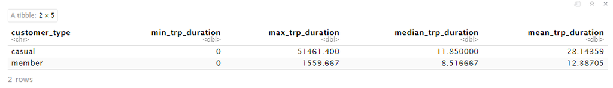

These summary statistics give you insights into how trip durations differ between “casual” and “member” customers. We observed that both “casual” and “member” customers can have very short trips, with a minimum trip duration of 0 minutes. This indicates that some cyclist, regardless of their type, use our services for quick trips. The “Casual” customers can have significantly longer trips, with a maximum trip duration reaching as high as 51461.400 minutes. In contrast, “member” customers tend to have shorter trips, with a maximum duration of 1559.667 minutes. This suggests that “casual” customers are more likely to use our services for extended journeys. The median trip duration for “casual” customers is approximately 11.85 minutes, while for “member” customers, it’s approximately 8.51 minutes. On average, “casual” customers have longer trips, with an average trip duration of approximately 28.14 minutes, compared to “member” customers, who have an average trip duration of approximately 12.38 minutes.

Order day_of_week column for easier reference

```r
df_processed_v2$day_of_week <- ordered(df_processed_v2$day_of_week, levels=c("Mon","Tue","Wed","Thu","Fri","Sat","Sun"))
```

Order month column

```r
# Create a vector of ordered months in the desired order
ordered_months <- c("Aug_22", "Sep_22", "Oct_22", "Nov_22","Dec_22","Jan_23", "Feb_23", "Mar_23","Apr_23", "May_23","Jun_23","Jul_23")
# Apply the ordered levels to the month column
df_processed_v2$month <- ordered(df_processed_v2$month, levels = ordered_months)
```

Summarize into Table

```r
df_processed_v2 %>% group_by(customer_type, day_of_week) %>%
  summarise(number_of_rides = n(), average_duration_min = mean(trip_duration)) %>%
  arrange(customer_type, desc(number_of_rides))
```

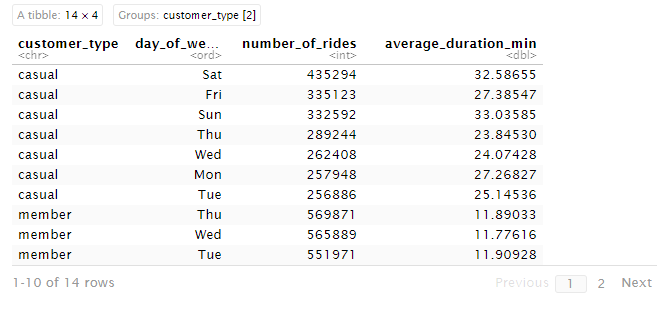

**Visualization1**

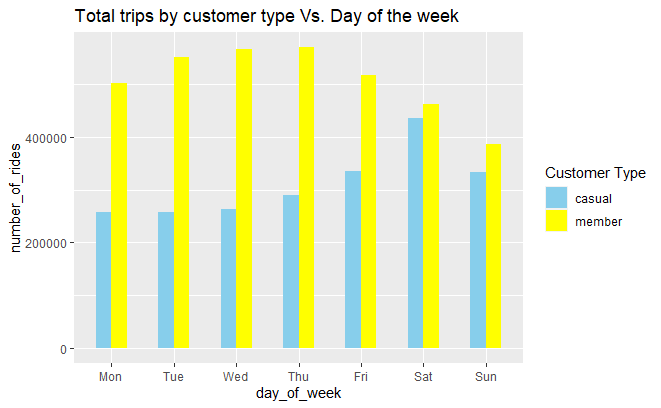

```r
df_processed_v2 %>% group_by(customer_type, day_of_week) %>%
  summarise(number_of_rides = n()) %>%
  arrange(customer_type, day_of_week) %>%
  ggplot(aes(x = day_of_week, y = number_of_rides, fill = customer_type)) +
  labs(title = "Total trips by customer type Vs. Day of the week",
       fill = "Customer Type") +
  geom_col(width = 0.5, position = position_dodge(width = 0.5)) +
  scale_y_continuous(labels = function(x) format(x, scientific = FALSE)) +
  scale_fill_manual(values = c("skyblue", "yellow"))
```

Average number of trip by customer type and month

```r
df_processed_v2 %>% group_by(customer_type, month) %>%
  summarise(number_of_rides = n(), average_duration_mins = mean(trip_duration))
```

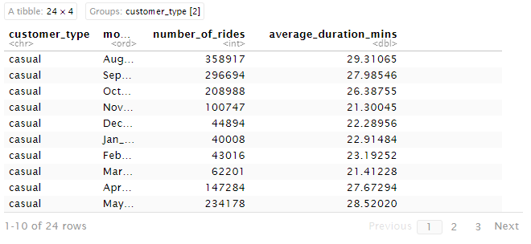

**Visualization 2**

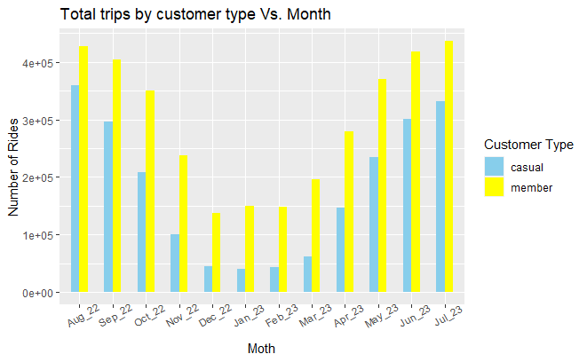

```r
# Create the ggplot chart
df_processed_v2 %>%   group_by(customer_type, month) %>%
  summarise(number_of_rides = n()) %>%   arrange(customer_type, month) %>%
  ggplot(aes(x = month, y = number_of_rides, fill = customer_type)) +
  geom_col(width = 0.5, position = "dodge") +
  labs(title = "Total trips by customer type Vs. Month",
       x = "Moth",
       y = "Number of Rides",
       fill = "Customer Type") +
  theme(axis.text.x = element_text(angle = 30)) +
  scale_fill_manual(values = c("skyblue", "yellow"))
```

**Visualisation 3**

```r
df_processed_v2 %>%
  group_by(customer_type, day_of_week) %>%
  summarise(average_trip_duration = mean(trip_duration)) %>%
  ggplot(aes(x = day_of_week, y = average_trip_duration, fill = customer_type)) +
  geom_col(width = 0.5, position = position_dodge(width = 0.5)) +
  labs(title = "Average trip duration by customer type Vs. Day of the week",
       fill = "Customer Type",
       x = "Trip Duration",
       y = "Day of Week")+
  scale_fill_manual(values = c("skyblue", "yellow"))
```

[output not shown]

**Visualization 4**

```r
df_processed_v2 %>%
  group_by(customer_type, month) %>%
  summarise(average_trip_duration = mean(trip_duration)) %>%
  ggplot(aes(x = month, y = average_trip_duration, fill = customer_type)) +
  geom_col(width=0.5, position = position_dodge(width=0.5)) +
  labs(title ="Average trip duration by customer type Vs. Month",
       x = "Month",
       y = "Average Trip Duration",
       fill = "Customer Type") +
  theme(axis.text.x = element_text(angle = 30))+
  scale_fill_manual(values = c("skyblue", "yellow"))
```

[figure not shown]

**Visualization 5**

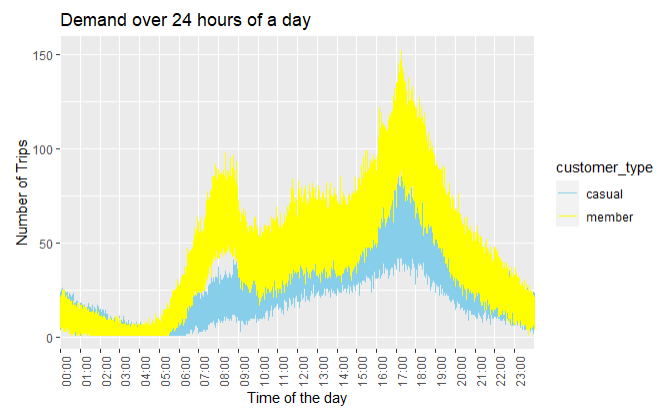

```r
# Create the ggplot chart
df_processed_v2 %>%
  group_by(customer_type, time) %>%
  summarise(number_of_trips = n()) %>%
  ggplot(aes(x = time, y = number_of_trips, color = customer_type, group = customer_type)) + geom_line() +
  scale_x_datetime(date_breaks = "1 hour", minor_breaks = NULL, date_labels = "%H:%M", expand = c(0, 0)) +
  theme(axis.text.x = element_text(angle = 90)) +
  labs(title = "Demand over 24 hours of a day",
       x = "Time of the day",
       y = "Number of Trips",
       fill = "Customer Type") +
  scale_colour_manual(values = c("skyblue", "yellow"))
```

Save the cleaned and processed data frame.

```r
write.csv(df_processed_v2, "C:\\Users\\Acer\\Documents\\R Programming\\ProjectDF_PROCESS_V2.csv", row.names = FALSE)
```

Open Tableau.

Count unique **start_lat** and **start_lng** for casual riders targeted in marketing efforts.

`{STR([start_lat]) + ", " + STR([start_lng])}`

[figure not shown]

     `STR([end_lat]) + ", " + STR([end_lng])`

[figure not shown]

# ACT PHASE

In this section we transition from data analysis to actionable insights. Here, we take the valuable findings extracted from our analysis and translate them into practical recommendations for real-world applications. This phase is where the rubber meets the road, as we identify the steps and strategies that can drive positive change within the organization. By distilling complex data into clear and actionable recommendations, we empower businesses to make informed decisions, optimize processes, and ultimately achieve their goals. In this phase, we bridge the gap between data analysis and meaningful impact, turning insights into action for the benefit of the organization.

## **Top Three Recommendations based on Analysis:**

1. Understanding User Behavior:

Tailor the user experience on the Cyclistic app or website to cater to the distinct preferences of annual members and casual riders. This might involve personalized recommendations, exclusive offers, or ride suggestions based on historical usage patterns. Also communicate the advantages of annual memberships compared to pay-as-you-go options, such as cost savings, convenience, and priority access to bikes. Utilize intuitive infographics and testimonials to convey these benefits effectively.

2. Encouraging Casual Riders to Go Annual:

Introduce a limited-time trial annual membership at a discounted rate for casual riders. This allows them to experience the convenience and savings of an annual membership before committing fully. Develop a loyalty program that rewards frequent casual riders with exclusive perks and discounts, creating an incentive to transition to annual membership. Highlight the long-term value and cost-efficiency of annual membership compared to single rides.

3. Leveraging Digital Media:

Utilize data-driven insights to craft highly targeted digital marketing campaigns. Focus on demographics, locations, and interests of casual riders who exhibit characteristics indicative of potential annual members. Create engaging and informative content, such as blog posts, videos, and social media campaigns, that highlights the benefits of becoming an annual member. Showcase real-life success stories of riders who made the switch. Collaborate with local influencers or cycling enthusiasts to endorse Cyclistic’s annual memberships. Their authentic recommendations can resonate with casual riders and motivate them to join.

## **Conclusion**

In conclusion, the analysis of Cyclistic’s bike trip data has unveiled valuable insights into user behavior, trip patterns, and preferences. These insights offer actionable recommendations to improve the user experience, enhance marketing strategies, and optimize service coverage. By implementing the top three recommendations mentioned above, Cyclistic can effectively cater to the needs of its diverse user base, boost ridership, and drive business growth.